# Creation of ESCS final

Kirsten van Kessel

2023-11-09

#### Create the right values for 2PL

To make sure we can perform the 2PL analysis, we need to: - Select country, student id, questionnaire language, and the ST011, ST012, and ST013 variables. - Remove the labels of the ST011, ST012, and ST013 variables. Otherwise they won’t work in analyses. - Recode ST011, so that a higher level indicates the presence of the indicator. - Recode the country specific ST011 items to 0, 1, and NA, instead of a specific value per country. - Make sure all the variables have a zero value.

```r
# select all necessary variables
data_homepos <- data %>% dplyr::select(CNT, CNTSTUID, LANGTEST_QQQ, ST011Q01TA:ST011Q16NA, ST011D17TA:ST011D19TA, ST012Q01TA:ST012Q09NA, ST013Q01TA)

# select ST011 variables to recode
data_ST011 <- data %>% dplyr::select(ST011Q01TA:ST011Q16NA)

# Make ST011 numeric (to remove labels)
data_homepos[colnames(data_ST011)] <- sapply(data_homepos[colnames(data_ST011)],as.numeric)

# Recode ST011
data_homepos <- data_homepos %>% mutate_at(vars(all_of(colnames(data_ST011))), list(~recode(., '1' = 1, '2' = 0)))

# select ST011 country specific variables
data_ST011_CS <- data_homepos %>% dplyr::select(ST011D17TA:ST011D19TA)

# Make ST011 country specific variables characters to remove labels
data_homepos[colnames(data_ST011_CS)] <- sapply(data_homepos[colnames(data_ST011_CS)],as.character)

# Make ST011 country specific variables numeric
data_homepos[colnames(data_ST011_CS)] <- sapply(data_homepos[colnames(data_ST011_CS)],as.numeric)

# make function to recode CS variables to 0, 1, NA
recode_CS <- function(var){
  var[var %% 2 == 0 & var < 9999996] <- 0
  var[var %% 2 == 1 & var < 9999996] <- 1
  var[var >= 9999997] <- NA
  return(var)
}

# apply function
data_homepos[colnames(data_ST011_CS)] <- sapply(data_homepos[colnames(data_ST011_CS)],recode_CS)

# select all other variables
data_rest <- data %>% dplyr::select(ST012Q01TA:ST013Q01TA)

# make numeric to remove labels
data_homepos[colnames(data_rest)] <- sapply(data_homepos[colnames(data_rest)],as.numeric)

# make sure they have a 0 value
data_homepos[colnames(data_rest)] <- data_homepos[colnames(data_rest)] - 1

## All variables now have the right values for the 2PL ##
```

#### Create the right dataset for 2PL using dexterMML

The data is not yet in the right format. To use dexterMML on the data, we: - Make the data long format. - Give all the items that together get a separate parameter estimate a different item_id. This means that most items just get the item as item_id, country specific items get item_country as item_id, and language specific items get item_country_language as item_id.

```r
# make long format dataset
data_homepos_long <- data_homepos %>% pivot_longer(cols = c("ST011Q01TA":"ST013Q01TA"),
                                                    names_to = "item",
                                                    values_to = "item_score")

colnames(data_homepos_long)[colnames(data_homepos_long) == 'CNTSTUID'] <- 'person_id'

# create variable item_id
data_homepos_long$item_id <- data_homepos_long$item

# give all the CS variables an unique item_id per country
items_CS <- c("ST011Q07TA", "ST011Q08TA", "ST011D17TA", "ST011D18TA", "ST011D19TA", "ST012Q03TA")
for(var in items_CS){
  data_homepos_long$item_id[data_homepos_long$item_id == var] <- paste(
                                                    data_homepos_long$item[data_homepos_long$item_id == var],
                                                    data_homepos_long$CNT[data_homepos_long$item_id == var],
                                                    sep = "_")
}

# give all the group specific variables an unique item_id per group
## this did not work (yet) to put into a function or loop ##

# ST011Q01TA Saudi Arabia (Arabic, English)
table(data_homepos_long$LANGTEST_QQQ[data_homepos_long$CNT == "SAU"])
```

```
##
##    313    500
##   1375 152025
```

```r
data_homepos_long$item_id[data_homepos_long$item == "ST011Q01TA" & data_homepos_long$CNT == "SAU"] <- paste(
                                                    "ST011Q01TA", "SAU", sep = "_")

# ST011Q05TA Japan (Japanese)
table(data_homepos_long$LANGTEST_QQQ[data_homepos_long$CNT == "JPN"])
```

```
##
##    286
## 152675
```

```r
data_homepos_long$item_id[data_homepos_long$item == "ST011Q05TA" & data_homepos_long$CNT == "JPN"] <- paste(
                                                    "ST011Q05TA", "JPN", sep = "_")

# ST011Q09TA Japan (Japanese)
data_homepos_long$item_id[data_homepos_long$item == "ST011Q09TA" & data_homepos_long$CNT == "JPN"] <- paste(
                                                    "ST011Q09TA", "JPN", sep = "_")

# ST011Q11TA Finland (Finnish)
table(data_homepos_long$LANGTEST_QQQ[data_homepos_long$CNT == "FIN"])
```

```
##
##    420    494
## 130650   9600
```

```r
data_homepos_long$item_id[data_homepos_long$item == "ST011Q11TA" & data_homepos_long$CNT == "FIN" & data_homepos_long$LANGTEST_QQQ == 420] <- paste("ST011Q11TA", "FIN", "Finnish", sep = "_")

# ST011Q11TA Ireland (Irish, English)
table(data_homepos_long$LANGTEST_QQQ[data_homepos_long$CNT == "IRL"])
```

```
##
##    313    434
## 138225    725
```

```r
data_homepos_long$item_id[data_homepos_long$item == "ST011Q11TA" & data_homepos_long$CNT == "IRL"] <- paste(
                                                    "ST011Q11TA", "IRL", sep = "_")

# ST011Q12TA Qatar (Arabic)
table(data_homepos_long$LANGTEST_QQQ[data_homepos_long$CNT == "QAT"])
```

```
##
##    313    500
## 131925 210975
```

```r
data_homepos_long$item_id[data_homepos_long$item == "ST011Q12TA" & data_homepos_long$CNT == "QAT" & data_homepos_long$LANGTEST_QQQ == 500] <- paste("ST011Q12TA", "QAT", "Arabic", sep = "_")

# ST011Q12TA Saudi Arabia (Arabic, English)
table(data_homepos_long$LANGTEST_QQQ[data_homepos_long$CNT == "SAU"])
```

```
##
##    313    500
##   1375 152025
```

```r
data_homepos_long$item_id[data_homepos_long$item == "ST011Q12TA" & data_homepos_long$CNT == "SAU"] <- paste(
                                                    "ST011Q12TA", "SAU", sep = "_")

# ST011Q16NA Philippines (English)
table(data_homepos_long$LANGTEST_QQQ[data_homepos_long$CNT == "PHL"])
```

```
##
##    313
## 180775
```

```r
data_homepos_long$item_id[data_homepos_long$item == "ST011Q16NA" & data_homepos_long$CNT == "PHL"] <- paste(
                                                    "ST011Q16NA", "PHL", sep = "_")

# ST012Q01TA United Arab Emirates/Dubai (Arabic)
table(data_homepos_long$LANGTEST_QQQ[data_homepos_long$CNT == "ARE"])
```

```
##
##    313    500
## 236300 237575
```

```r
data_homepos_long$item_id[data_homepos_long$item == "ST012Q01TA" & data_homepos_long$CNT == "ARE" & data_homepos_long$LANGTEST_QQQ == 500] <- paste("ST012Q01TA", "ARE", "Arabic", sep = "_")

# ST012Q01TA Argentina (Spanish)
table(data_homepos_long$LANGTEST_QQQ[data_homepos_long$CNT == "ARG"])
```

```
##
##    156
## 298900
```

```r
data_homepos_long$item_id[data_homepos_long$item == "ST012Q01TA" & data_homepos_long$CNT == "ARG"] <- paste(
                                                    "ST012Q01TA", "ARG", sep = "_")
# ST012Q01TA Chile (Spanish)
table(data_homepos_long$LANGTEST_QQQ[data_homepos_long$CNT == "CHL"])
```

```
##
##    156
## 187450
```

```r
data_homepos_long$item_id[data_homepos_long$item == "ST012Q01TA" & data_homepos_long$CNT == "CHL"] <- paste(
                                                    "ST012Q01TA", "CHL", sep = "_")

# ST012Q01TA Hong Kong (China) (English)
table(data_homepos_long$LANGTEST_QQQ[data_homepos_long$CNT == "HKG"])
```

```
##
##    313    316
##   8625 140125
```

```r
data_homepos_long$item_id[data_homepos_long$item == "ST012Q01TA" & data_homepos_long$CNT == "HKG" & data_homepos_long$LANGTEST_QQQ == 313] <- paste("ST012Q01TA", "HKG", "English", sep = "_")

# ST012Q01TA Hong Kong (China) (Chinese)
table(data_homepos_long$LANGTEST_QQQ[data_homepos_long$CNT == "HKG"])
```

```
##
##    313    316
##   8625 140125
```

```r
data_homepos_long$item_id[data_homepos_long$item == "ST012Q01TA" & data_homepos_long$CNT == "HKG" & data_homepos_long$LANGTEST_QQQ == 316] <- paste("ST012Q01TA", "HKG", "Chinese", sep = "_")

# ST012Q01TA Korea (Korean)
table(data_homepos_long$LANGTEST_QQQ[data_homepos_long$CNT == "KOR"])
```

```
##
##    301
## 166025
```

```r
data_homepos_long$item_id[data_homepos_long$item == "ST012Q01TA" & data_homepos_long$CNT == "KOR"] <- paste(
                                                    "ST012Q01TA", "KOR", sep = "_")
# ST012Q01TA Qatar (Arabic)
table(data_homepos_long$LANGTEST_QQQ[data_homepos_long$CNT == "QAT"])
```

```
##
##    313    500
## 131925 210975
```

```r
data_homepos_long$item_id[data_homepos_long$item == "ST012Q01TA" & data_homepos_long$CNT == "QAT" & data_homepos_long$LANGTEST_QQQ == 500] <- paste("ST012Q01TA", "QAT", "Arabic", sep = "_")

# ST012Q01TA United States (English)
table(data_homepos_long$LANGTEST_QQQ[data_homepos_long$CNT == "USA"])
```

```
##
##    313
## 120100
```

```r
data_homepos_long$item_id[data_homepos_long$item == "ST012Q01TA" & data_homepos_long$CNT == "USA"] <- paste(
                                                    "ST012Q01TA", "USA", sep = "_")

# ST012Q02TA United Arab Emirates/Dubai (Arabic)
table(data_homepos_long$LANGTEST_QQQ[data_homepos_long$CNT == "ARE"])
```

```
##
##    313    500
## 236300 237575
```

```r
data_homepos_long$item_id[data_homepos_long$item == "ST012Q02TA" & data_homepos_long$CNT == "ARE" & data_homepos_long$LANGTEST_QQQ == 500] <- paste("ST012Q02TA", "ARE", "Arabic", sep = "_")

# ST012Q02TA Brunei Darussalam (English)
table(data_homepos_long$LANGTEST_QQQ[data_homepos_long$CNT == "BRN"])
```

```
##
##    313
## 170575
```

```r
data_homepos_long$item_id[data_homepos_long$item == "ST012Q02TA" & data_homepos_long$CNT == "BRN"] <- paste(
                                                    "ST012Q02TA", "BRN", sep = "_")
# ST012Q02TA Hong Kong (China) (Chinese)
table(data_homepos_long$LANGTEST_QQQ[data_homepos_long$CNT == "HKG"])
```

```
##
##    313    316
##   8625 140125
```

```r
data_homepos_long$item_id[data_homepos_long$item == "ST012Q02TA" & data_homepos_long$CNT == "HKG" & data_homepos_long$LANGTEST_QQQ == 316] <- paste("ST012Q02TA", "HKG", "Chinese", sep = "_")

# ST012Q02TA Hong Kong (China) (English)
table(data_homepos_long$LANGTEST_QQQ[data_homepos_long$CNT == "HKG"])
```

```
##
##    313    316
##   8625 140125
```

```r
data_homepos_long$item_id[data_homepos_long$item == "ST012Q02TA" & data_homepos_long$CNT == "HKG" & data_homepos_long$LANGTEST_QQQ == 313] <- paste("ST012Q02TA", "HKG", "English", sep = "_")

# ST012Q02TA Malaysia (English)
table(data_homepos_long$LANGTEST_QQQ[data_homepos_long$CNT == "MYS"])
```

```
##
##    204    313
## 129900  22850
```

```r
data_homepos_long$item_id[data_homepos_long$item == "ST012Q02TA" & data_homepos_long$CNT == "MYS" & data_homepos_long$LANGTEST_QQQ == 313] <- paste("ST012Q02TA", "MYS", "English", sep = "_")

# ST012Q02TA Qatar (Arabic)
table(data_homepos_long$LANGTEST_QQQ[data_homepos_long$CNT == "QAT"])
```

```
##
##    313    500
## 131925 210975
```

```r
data_homepos_long$item_id[data_homepos_long$item == "ST012Q02TA" & data_homepos_long$CNT == "QAT" & data_homepos_long$LANGTEST_QQQ == 500] <- paste("ST012Q02TA", "QAT", "Arabic", sep = "_")

# ST012Q02TA Saudi Arabia (Arabic, English)
table(data_homepos_long$LANGTEST_QQQ[data_homepos_long$CNT == "SAU"])
```

```
##
##    313    500
##   1375 152025
```

```r
data_homepos_long$item_id[data_homepos_long$item == "ST012Q02TA" & data_homepos_long$CNT == "SAU"] <- paste(
                                                    "ST012Q02TA", "SAU", sep = "_")

# ST012Q02TA Singapore (English)
table(data_homepos_long$LANGTEST_QQQ[data_homepos_long$CNT == "SGP"])
```

```
##
##    313
## 166650
```

```r
data_homepos_long$item_id[data_homepos_long$item == "ST012Q02TA" & data_homepos_long$CNT == "SGP"] <- paste(
                                                    "ST012Q02TA", "SGP", sep = "_")

# ST012Q02TA United States (English)
table(data_homepos_long$LANGTEST_QQQ[data_homepos_long$CNT == "USA"])
```

```
##
##    313
## 120100
```

```r
data_homepos_long$item_id[data_homepos_long$item == "ST012Q02TA" & data_homepos_long$CNT == "USA"] <- paste(
                                                    "ST012Q02TA", "USA", sep = "_")

# ST012Q02TA Viet Nam (Vietnamese)
table(data_homepos_long$LANGTEST_QQQ[data_homepos_long$CNT == "VNM"])
```

```
##
##    329
## 134425
```

```r
data_homepos_long$item_id[data_homepos_long$item == "ST012Q02TA" & data_homepos_long$CNT == "VNM"] <- paste(
                                                    "ST012Q02TA", "VNM", sep = "_")

# ST012Q05NA Kazakhstan (Kazakh)
table(data_homepos_long$LANGTEST_QQQ[data_homepos_long$CNT == "KAZ"])
```

```
##
##    275    495
## 286225 201300
```

```r
data_homepos_long$item_id[data_homepos_long$item == "ST012Q05NA" & data_homepos_long$CNT == "KAZ" & data_homepos_long$LANGTEST_QQQ == 275] <- paste("ST012Q05NA", "KAZ", "Kazakh", sep = "_")

# ST012Q05NA Republic of Moldova (Russian)
table(data_homepos_long$LANGTEST_QQQ[data_homepos_long$CNT == "MDA"])
```

```
##
##    118    495
## 108775  25400
```

```r
data_homepos_long$item_id[data_homepos_long$item == "ST012Q05NA" & data_homepos_long$CNT == "MDA" & data_homepos_long$LANGTEST_QQQ == 495] <- paste("ST012Q05NA", "MDA", "Russian", sep = "_")

# ST012Q06NA Denmark (Danish)
table(data_homepos_long$LANGTEST_QQQ[data_homepos_long$CNT == "DNK"])
```

```
##
##    264
## 189650
```

```r
data_homepos_long$item_id[data_homepos_long$item == "ST012Q06NA" & data_homepos_long$CNT == "DNK"] <- paste(
                                                    "ST012Q06NA", "DNK", sep = "_")

# ST012Q07NA United Arab Emirates/Dubai (Arabic)
table(data_homepos_long$LANGTEST_QQQ[data_homepos_long$CNT == "ARE"])
```

```
##
##    313    500
## 236300 237575
```

```r
data_homepos_long$item_id[data_homepos_long$item == "ST012Q07NA" & data_homepos_long$CNT == "ARE" & data_homepos_long$LANGTEST_QQQ == 500] <- paste("ST012Q07NA", "ARE", "Arabic", sep = "_")

# ST012Q07NA Qatar (Arabic)
data_homepos_long$item_id[data_homepos_long$item == "ST012Q07NA" & data_homepos_long$CNT == "QAT" & data_homepos_long$LANGTEST_QQQ == 500] <- paste("ST012Q07NA", "QAT", "Arabic", sep = "_")

# ST012Q07NA Qatar (English)
data_homepos_long$item_id[data_homepos_long$item == "ST012Q07NA" & data_homepos_long$CNT == "QAT" & data_homepos_long$LANGTEST_QQQ == 313] <- paste("ST012Q07NA", "QAT", "English", sep = "_")
```

#### Perform 2PL with dexterMML

To get the ability estimates, i.e., HOMEPOS, we perform a 2PL. We need to: - Make sure only the complete cases are used. - Calculate parameter estimates. - Calculate the ability estimates per student (= HOMEPOS).

```r
# drop the items where a score is missing
data_homepos_long_complete <- data_homepos_long %>% drop_na(item_score)

# estimate the parameters
parms <- dexterMML::fit_2pl(data_homepos_long_complete %>% dplyr::select(person_id, item_id, item_score))
coef(parms)
```

```
## # A tibble: 732 × 6
##    item_id        alpha item_score    beta SE_alpha SE_beta
##    <chr>          <dbl>      <int>   <dbl>    <dbl>   <dbl>
##  1 ST011D17TA_ALB 0.911          1 -2.66     0.0511  0.104
##  2 ST011D17TA_ARE 1.22           1 -0.983    0.0277  0.0235
##  3 ST011D17TA_ARG 0.929          1 -2.13     0.0325  0.0517
##  4 ST011D17TA_AUS 0.609          1  1.64     0.0288  0.0503
##  5 ST011D17TA_AUT 0.970          1 -1.47     0.0560  0.100
##  6 ST011D17TA_BEL 0.362          1  0.0830   0.0322  0.0677
##  7 ST011D17TA_BGR 1.50           1 -2.44     0.0961  0.115
##  8 ST011D17TA_BIH 1.15           1 -2.25     0.0742  0.119
##  9 ST011D17TA_BLR 2.27           1 -2.17     0.189   0.115
## 10 ST011D17TA_BRA 0.780          1 -2.47     0.0333  0.0672
## # ℹ 722 more rows
```

```r
# calculate theta: the ability estimate
theta <- ability.mml(data_homepos_long_complete, parms, method = "WLE")
```

#### Compare computed homepos with PISA homepos

To know how well we recreated HOMEPOS, we compare the calculated HOMEPOS with the original PISA HOMEPOS. We do this by: - Looking at the correlation between calculated HOMEPOS and PISA HOMEPOS. - Looking at a scatter plot between calculated HOMEPOS and PISA HOMEPOS.

```r
# make a dataframe with original pisa data
data_compare <- data.frame(person_id = data$CNTSTUID, HOMEPOS_PISA = data$HOMEPOS)

# drop missings
data_compare <- data_compare %>% drop_na()

# add calculated homepos
data_compare <- merge(data_compare, theta, by = "person_id")

# compare
summary(data_compare$HOMEPOS_PISA)
```

```
##     Min.  1st Qu.   Median     Mean  3rd Qu.     Max.
## -10.2033  -1.1218  -0.3722  -0.4370   0.3019   5.9236
```

```r
summary(data_compare$theta)
```

```
##      Min.   1st Qu.    Median      Mean   3rd Qu.      Max.
## -9.550362 -0.673857  0.028188 -0.005414  0.686326  6.987412
```

```r
cor(data_compare$HOMEPOS_PISA, data_compare$theta)
```

```
## [1] 0.9967548
```

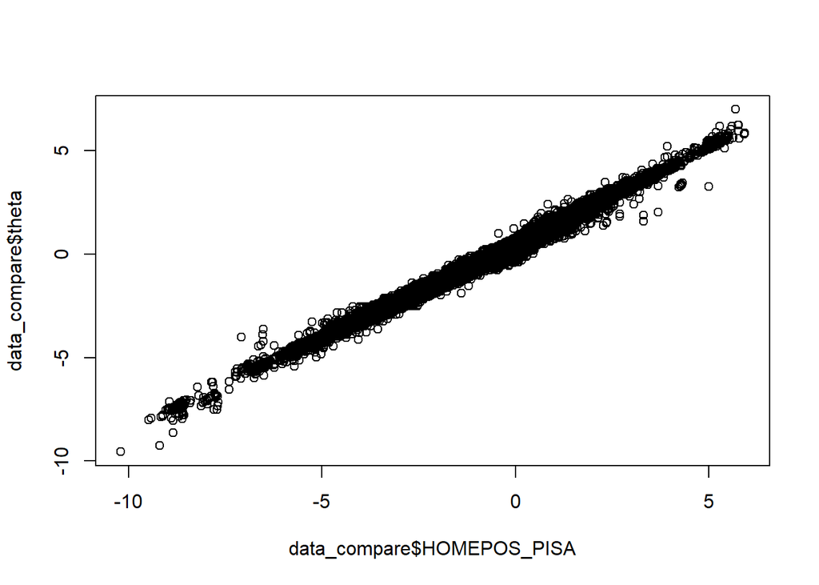

```r
plot(data_compare$HOMEPOS_PISA, data_compare$theta)
```

[figure not shown]

```r
HOMEPOS_plot <- ggplot(data_compare, aes(x = HOMEPOS_PISA, y = theta)) + geom_point(alpha = 0.05) +
  ggtitle("Comparing computed HOMEPOS to the PISA HOMEPOS") +
  xlab("Computed HOMEPOS") + ylab("PISA HOMEPOS")
HOMEPOS_plot
```

#### Create dataset for recreating ESCS

To recreate ESCS, we need more variables, so we create a new dataset with only the necessary variables.

```r
# Change the column names so they make sense in the original data
colnames(theta) <- c("CNTSTUID", "HOMEPOS_theta", "HOMEPOS_se")

# add our created HOMEPOS to the data
data <- merge(data, theta, by = "CNTSTUID", all.x = TRUE)

# make data with only indicators
data_ind2 <- data.frame(data$CNT, data$HISEI, data$PAREDINT, data$HOMEPOS_theta, data$CNTSTUID)
data_ind2$data.CNT <- as.character(data_ind2$data.CNT)
data_ind2$data.HISEI <- as.numeric(data_ind2$data.HISEI)
data_ind2$data.PAREDINT <- as.numeric(data_ind2$data.PAREDINT)
data_ind2$data.HOMEPOS <- as.numeric(data_ind2$data.HOMEPOS_theta)

# add variable that indicates number of missings per row
data_ind2 <- data_ind2 %>% mutate(n_NAs = rowSums(is.na(.)))
```

#### Imputation

To recreate ESCS, we first need to impute the values of the indicators. This is done using stochastic regression imputation per country and only if the student has a missing value on exactly one of the three indicators.

```r
# make a list of countries
country_list <- unique(data_ind2$data.CNT)

# make a data frame to save the imputed data of the countries
data_all <- data.frame()

set.seed(679)

# for each country
for(country in country_list){

data_ind <- data_ind2 %>% filter(data.CNT == country)

# HOMEPOS
model_home <- lm(data = data_ind, data.HOMEPOS ~ data.PAREDINT + data.HISEI)
summary(model_home)

data_im <- data_ind %>% mutate(homepos_im = case_when(
  is.na(data.HOMEPOS) & n_NAs == 1 ~ model_home$coefficients[1] + model_home$coefficients[2]*data.PAREDINT + model_home$coefficients[3]*data.HISEI + rnorm(1, 0, summary(model_home)$sigma),
  TRUE ~ data.HOMEPOS))

# PAREDINT
model_paredint <- lm(data = data_ind, data.PAREDINT ~ data.HOMEPOS + data.HISEI)
summary(model_paredint)

data_im <- data_im %>% mutate(paredint_im = case_when(
  is.na(data.PAREDINT) & n_NAs == 1 ~ model_paredint$coefficients[1]
 + model_paredint$coefficients[2]*data.HOMEPOS + model_paredint$coefficients[3]*data.HISEI + rnorm(1, 0, summary(model_paredint)$sigma),
  TRUE ~ data.PAREDINT
  ))

# HISEI
model_hisei <- lm(data = data_ind, data.HISEI ~ data.PAREDINT + data.HOMEPOS)
summary(model_hisei)

data_im <- data_im %>% mutate(hisei_im = case_when(
  is.na(data.HISEI) & n_NAs == 1 ~ model_hisei$coefficients[1] + model_hisei$coefficients[2]*data.PAREDINT + model_hisei$coefficients[3]*data.HOMEPOS + rnorm(1, 0, summary(model_hisei)$sigma),
  TRUE ~ data.HISEI
  ))

data_all <- rbind(data_all, data_im)
}
```

#### Scaling

Before we use the indicators to create ESCS, we scale the indicators to have a mean of 0 and a SD of 1.

```r
data_all$hisei_im <- scale(data_all$hisei_im)
data_all$homepos_im <- scale(data_all$homepos_im)
data_all$paredint_im <- scale(data_all$paredint_im)
```

#### Creating ESCS and comparing to PISA’s ESCS

We recreate ESCS by taking the mean of the three imputed and scaled indicators. To know how well we recreated ESCS, we compare the calculated ESCS with the original PISA ESCS. We do this by: - Looking at the correlation between calculated ESCS and PISA ESCS - Looking at a scatter plot between calculated ESCS and PISA ESCS

```r
# add ESCS to dataframe
data_all$ESCS <- apply(cbind(data_all$homepos_im, data_all$paredint_im, data_all$hisei_im), 1, mean, na.rm = FALSE)

# compare created ESCS to the ESCS in the PISA data
data_all$ESCS_PISA <- data$ESCS
summary(data_all$ESCS)
```

```
##    Min. 1st Qu.  Median    Mean 3rd Qu.    Max.    NA's
##  -4.867  -0.533   0.059   0.000   0.629   3.458   14087
```

```r
summary(data_all$ESCS_PISA)
```

```
##    Min. 1st Qu.  Median    Mean 3rd Qu.    Max.    NA's
##  -8.173  -1.010  -0.188  -0.281   0.594   4.205   14379
```

```r
cor(data_all$ESCS,data_all$ESCS_PISA, use = "complete")
```

```
## [1] 0.9912855
```

[figure not shown]

```r
# create a plot
ESCS_plot <- ggplot(data_all, aes(x = ESCS_PISA, y = ESCS)) + geom_point(alpha = 0.05) +
  ggtitle("Comparing computed ESCS to the PISA ESCS") +
  xlab("Computed ESCS") + ylab("PISA ESCS")
ESCS_plot
```

The correlation between PISA’s ESCS and our ESCS is 0.9913.